# Replicate Comparison

Will Hannon

9/8/2020

### Overview

This notebook aims to assess our ability to call genomic variants accurately by comparing replicate sequencing runs.

The samples consist of 24 sequencing runs with a Ct value of less than 20. Originally, samples were sequenced once as part of [this study](https://doi.org/10.1101/2020.08.13.20173161). The runs with a low enough Ct value to be considered for re-sequencing by a shotgun metagenomic method were re-sequenced as replicates. One sample is currently excluded from this analysis because it is not included on the SRA (`SpID: 10110`), leaving 23 final samples.

By comparing the allele frequency of variants called in both replicates, we hope to assess the accuracy, the optimal frequency cutoff, and the optimal coverage cutoff for downstream bottleneck analyses.

### Variant Calling

For this preliminary analysis, I aligned the samples with `BWA,` and called variants with `Varscan`. Ideally, all variant alleles will be identified by counting the number of bases over each position in the genome. However, to quickly get an idea of samples’ quality, I decided to approximate this with `Varscan`. I removed any filters for minimum allele frequency, depth, or supporting reads.

### Replicate Information

The critical difference between the replicates is the processing. The samples on the SRA underwent a slightly different pre-processing pipeline to remove human reads and trim adaptors. Eventually, I’ll re-process the raw files to make the pipelines identical.

Here, I’m comparing the difference in the number of mapped reads between replicates. There are some substantial differences between replicates, but I’m not sure if this is because of processing or sequencing differences.

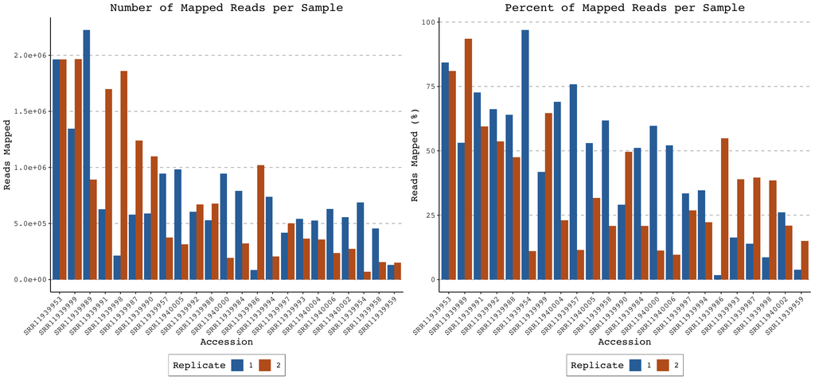

### Coverage

I calculated the coverage over the genome in 50bp increments. I flitered out the last 53 bp (2 bins) of the genome becuase there is a polyA tract with a tremendous amount of reads that align. These skew the coverage visualization. Figuring out a better way to align this section is important.

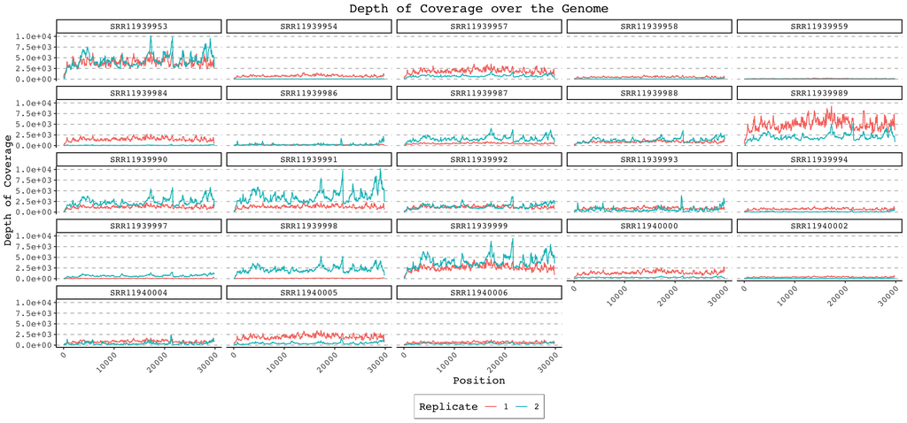

### Consensus Variants

The optimal way to classify and filter consensus variants is to do it before reads are aligned, and the final variant alleles are called. However, by identifying consensus variants at this stage, I can check for any systematic biases or samples that might skew the cohort’s consensus sequence.

To identify consensus variants, I filtered for any variants that appear at greater than or equal to 50% frequency in either replicate and counted the number of samples with these variants.

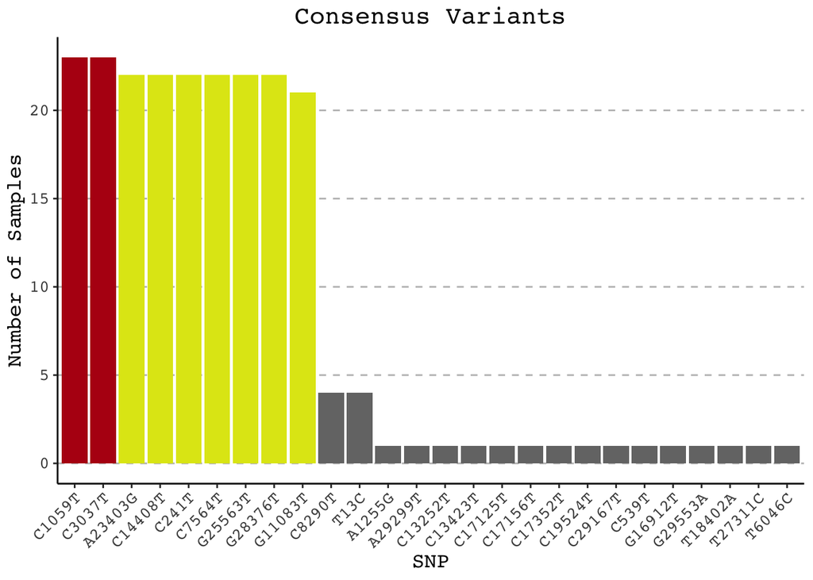

There are two SNPs (indicated in Red) that show up in all 23 samples. There are another ~7 SNPs that are likely consensus variants, but are missing from either one or two samples (or replicates).

I was curious if these SNPs present in 21 or 22 samples were genuinely absent from the remaining samples. I checked if there was a bias in what samples were missing consensus variants.

```
## [1] "A23403G-SRR11939959"
## [1] "C14408T-SRR11939959"
## [1] "C241T-SRR11939959"
## [1] "C7564T-SRR11939986"
## [1] "G25563T-SRR11939986"
## [1] "G28376T-SRR11939986"
## [1] "G11083T-SRR11939986" "G11083T-SRR11939958"
```

There are two samples (`SRR11939959` and `SRR11939986`) that are missing three and four variants respectivley.

Samples Missing Consensus Variants

|  | Accession | Replicate | Reads Mapped | Percent Mapped | Depth |
| --- | --- | --- | --- | --- | --- |
| 7 | SRR11939958 | 2 | 155589 | 20.817534 | 369.4218 |
| 8 | SRR11939958 | 1 | 454944 | 61.758921 | 1095.4074 |
| 9 | SRR11939959 | 2 | 150975 | 15.068719 | 358.4665 |
| 10 | SRR11939959 | 1 | 130396 | 3.861836 | 313.9656 |
| 13 | SRR11939986 | 2 | 1021770 | 54.889163 | 2426.0332 |
| 14 | SRR11939986 | 1 | 85900 | 1.679103 | 206.8287 |

Samples `SRR11939959` and `SRR11939986` have at least one replicate with a very low percentage of reads mapped. The following SNPs were excluded becuase they were missing from a single replicate:

- `A23403G`
- `C14408T`
- `C241T`
- `G25563T`
- `G11083T`

These SNPs do appear to be true consensus SNPs. Two SNPs are genuinely missing from both replicates of `SRR11939986` and can’t be easily explained by low coverage:

- `C7564T`
- `G28376T`

Therefore, the following 7 SNPs are the true consensus SNPs and should be masked from downstream analyses.

```
## [1] "C1059T"  "C3037T"  "A23403G" "C14408T" "C241T"   "G25563T" "G11083T"
```

### Replicate Comparison

Next, I wanted to assess the variability in the frequency of alternative alleles called in each replicate. Samples with significant variability likely have low viral template number and can be excluded from downstream analyses. Additionally, I should be able to determine which samples need to be sequenced to higher depth.

I removed any samples with fewer than 3 alternative alleles at sites with at least 200X coverage. The result were 14 final samples, listed below.

```
##  [1] "SRR11939953" "SRR11939957" "SRR11939987" "SRR11939988" "SRR11939989"
##  [6] "SRR11939990" "SRR11939991" "SRR11939992" "SRR11939993" "SRR11939999"
## [11] "SRR11940000" "SRR11940004" "SRR11940005" "SRR11940006"
```

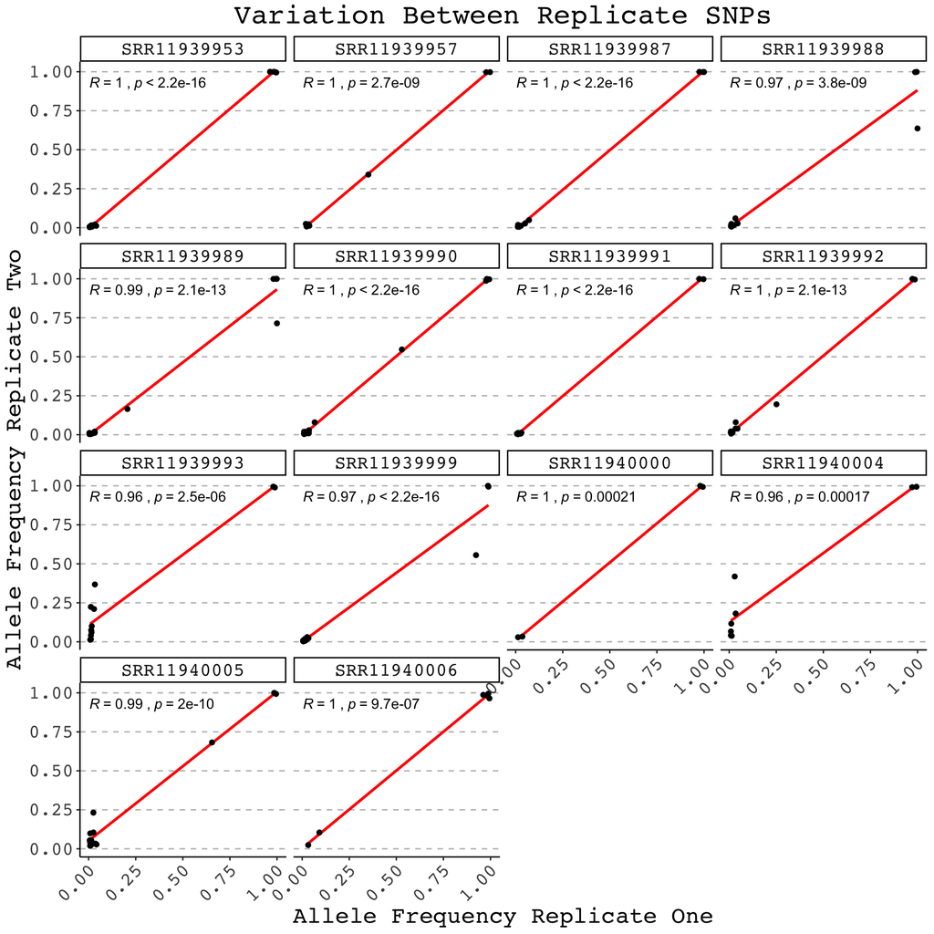

Generally, the correlation between variant allele frequencies looks high in all samples. However, this could be skewed by the samples’ heavily bimodal distribution, with high-frequency variants driving the correlation. Not many variants exist at intermediate frequencies. The variability in allele frequencies is better visualized after a log10 transformation.

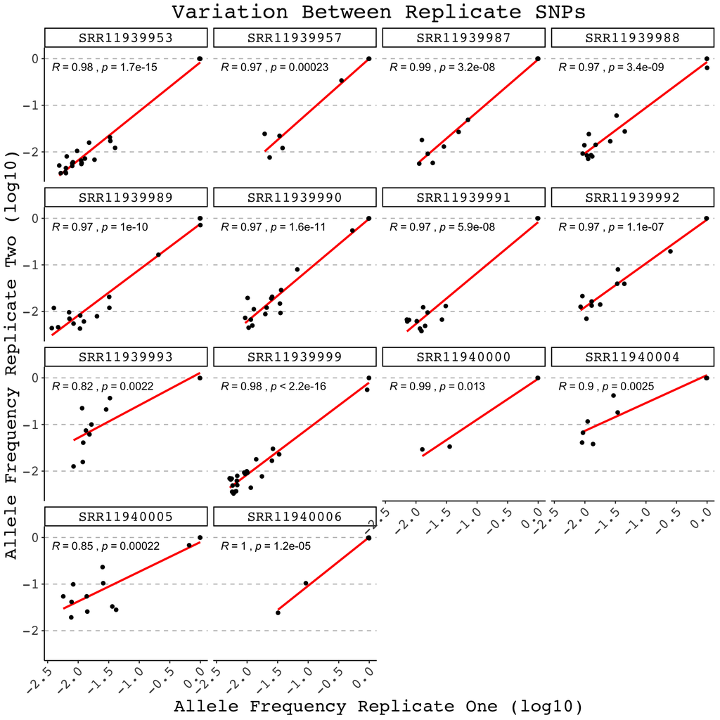

Even though these variants were processed with no filters, it looks like there are fewer than the variants called by varscan with filters. This is because the last round included InDels, which I have excluded from this analysis. It might make sense to see what these correlations look like with InDels included.

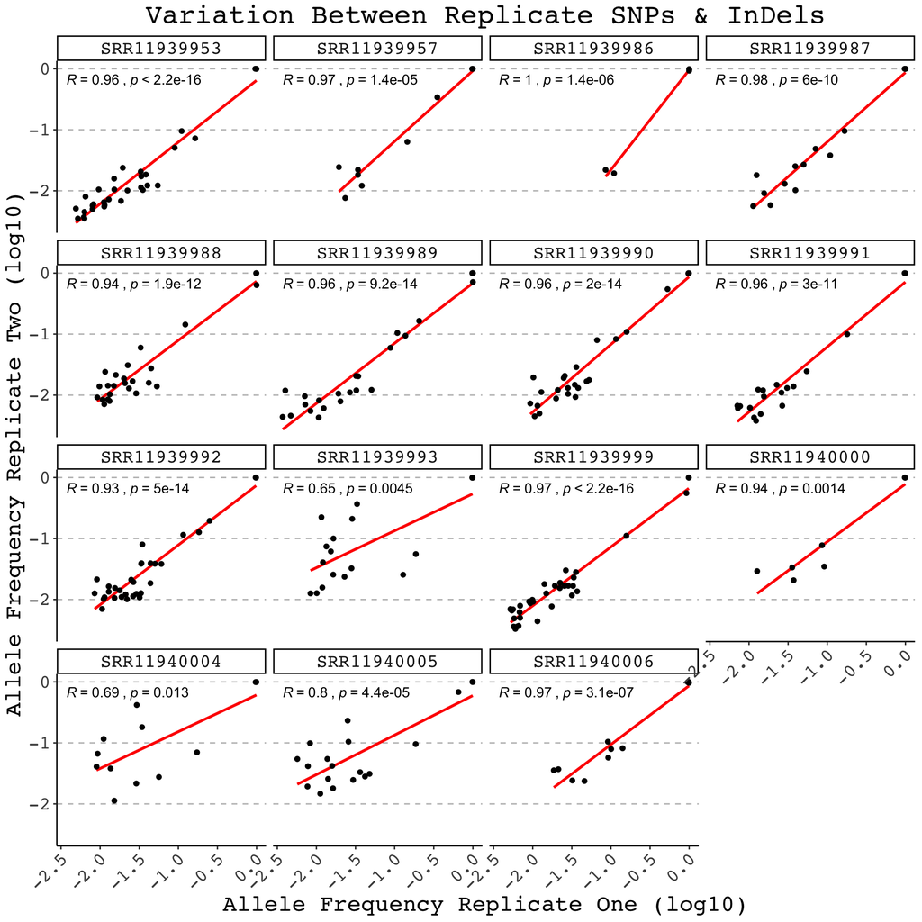

### Correlates of Low-Quality

Finally, I wanted to see which factors correlated the most strongly with low-quality replicates. The two factors I investigated were the Ct of the sample and the mean depth of the two replicates.

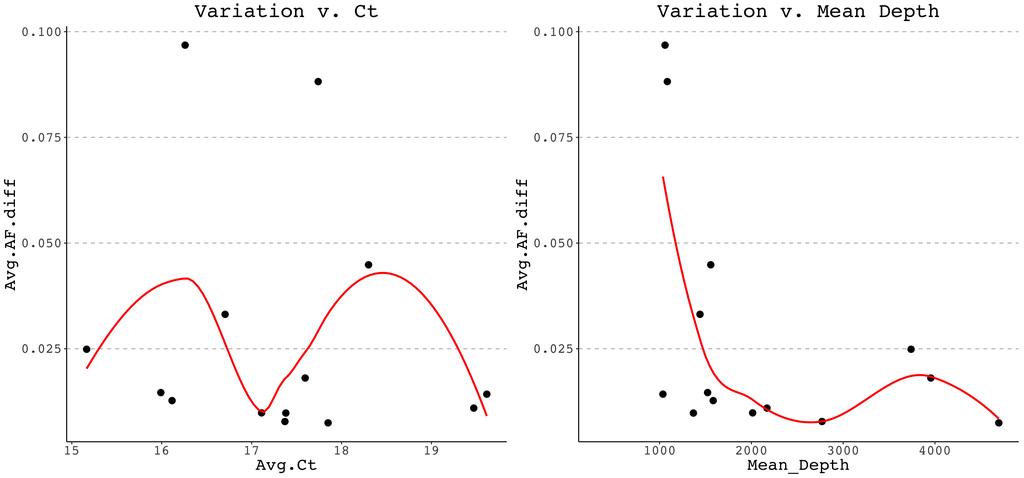

It seems like Ct value doesn’t correlate particularly well with the average difference between variant allele frequencies. There is a more clear relationship between mean depth and the average difference in allele frequencies.

### Shared Variants

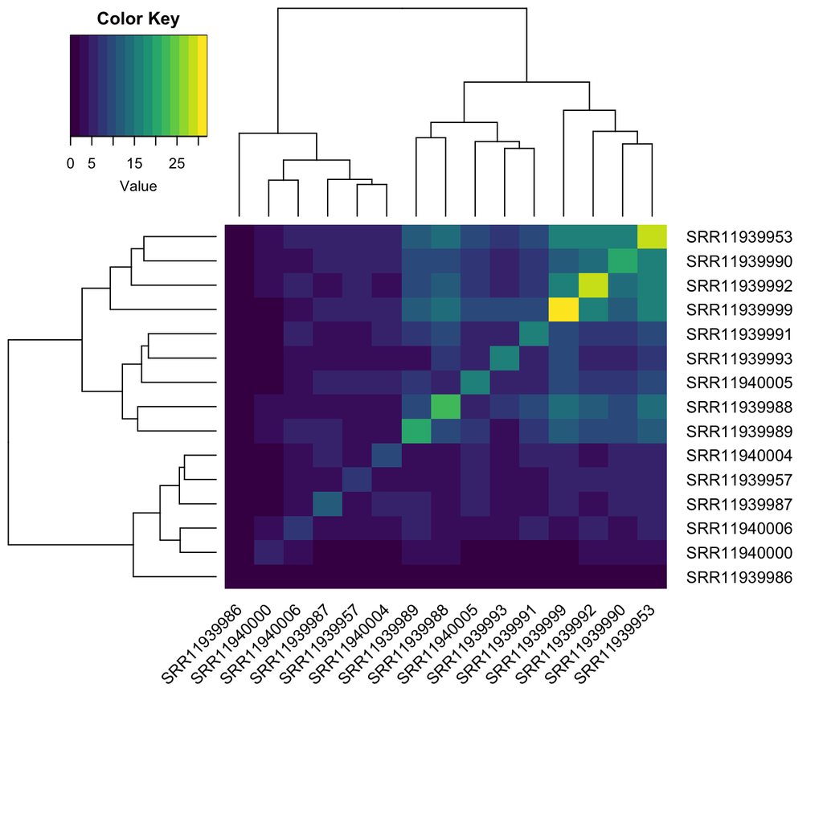

For the most part, the runs seem to cluster based on whether they have many variants or few variants. This is probably due to the depth. Should we make the case for sequncing to higher depth?

```
##             SRR11939989 SRR11939992 SRR11939957 SRR11940004 SRR11939988
## SRR11939989          20          10           4           4           9
## SRR11939992          10          29           5           4          11
## SRR11939957           4           5           7           4           4
## SRR11940004           4           4           4          10           4
## SRR11939988           9          11           4           4          22
## SRR11939990          10          14           5           6          10
## SRR11939991           7           8           4           5           9
## SRR11940000           3           3           2           2           3
## SRR11939999          11          15           5           6          13
## SRR11939993           4           5           3           4           7
## SRR11939953          11          16           5           5          13
## SRR11940005           7           8           5           6           6
## SRR11939986           1           0           0           0           0
## SRR11939987           6           4           4           5           4
## SRR11940006           5           5           3           3           4
##             SRR11939990 SRR11939991 SRR11940000 SRR11939999 SRR11939993
## SRR11939989          10           7           3          11           4
## SRR11939992          14           8           3          15           5
## SRR11939957           5           4           2           5           3
## SRR11940004           6           5           2           6           4
## SRR11939988          10           9           3          13           7
## SRR11939990          21           8           3          11           5
## SRR11939991           8          17           2           9           6
## SRR11940000           3           2           5           2           2
## SRR11939999          11           9           2          32           9
## SRR11939993           5           6           2           9          15
## SRR11939953          16           9           4          17           8
## SRR11940005           7           5           2          10           5
## SRR11939986           0           0           1           0           1
## SRR11939987           5           4           2           6           4
## SRR11940006           4           5           3           4           4
##             SRR11939953 SRR11940005 SRR11939986 SRR11939987 SRR11940006
## SRR11939989          11           7           1           6           5
## SRR11939992          16           8           0           4           5
## SRR11939957           5           5           0           4           3
## SRR11940004           5           6           0           5           3
## SRR11939988          13           6           0           4           4
## SRR11939990          16           7           0           5           4
## SRR11939991           9           5           0           4           5
## SRR11940000           4           2           1           2           3
## SRR11939999          17          10           0           6           4
## SRR11939993           8           5           1           4           4
## SRR11939953          29          10           1           6           6
## SRR11940005          10          16           0           6           3
## SRR11939986           1           0           2           1           1
## SRR11939987           6           6           1          11           4
## SRR11940006           6           3           1           4           8
```